# Modeling RT-QuIC Kinetics

Author

Gage Rowden

Published

July 14, 2026

## Introduction

This R package contains code for modeling the kinetics of the enzymes in the RT-QuIC assay. The enzymes are modeled using a two-component model, with the primary and secondary phases of the reaction being modeled separately.

The model is described by the following equations:

$$\begin{aligned}
G(t)&=\frac{S_1}{1+e^{a_1(b_1-\text{t})}}\\
D(t)&=\frac{S_2}{1+e^{a_2(b_2-\text{t})}}
\end{aligned}$$

where $S_1$ and $S_2$ represent the primary and secondary phase asymptotes, respectively. Parameters $a_1$ and $a_2$, modulate the steepness of the inflection point; $b_1$ and $b_2$ represent the midpoint of the inflection point of the curves. The model can be described as the sum of these two logistic functions.

$$f(t)=G(t)+D(t)$$

## Example Graph

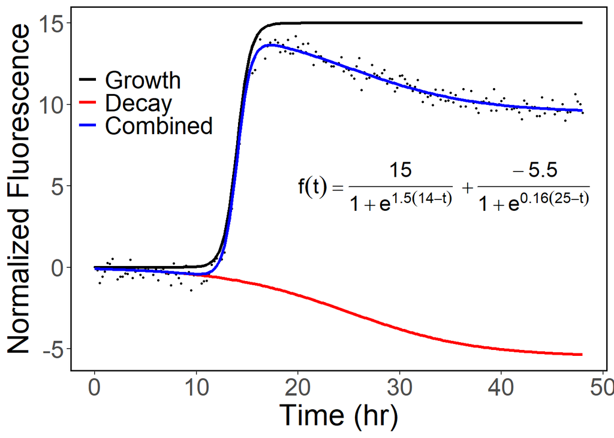

## How do the parameters affect the curves?

The $S$ parameter affects the height of the asymptote. For example, if $S=10$, the curve will approach 10 in the equillibrium phase as $t\rightarrow\infty$. If $S=0$, the other parameters will not affect the curve, and become redundant.

The $a$ parameter affects the steepness of the inflection point. A lower value of $a$ will result in a smoother curve, and as $a\rightarrow0$, the curve will approach a constant value at $S/2$. Alternatively, as $a\rightarrow\infty$, the curve will approach $S$ instantaneously at when $t=b$.

The $b$ parameter affects the timing of the inflection point (i.e. when the curve reaches $S/2$). This value can range from $-\infty\rightarrow\infty$, but for the purpose of this analysis, $b$ is constrained to positive values.

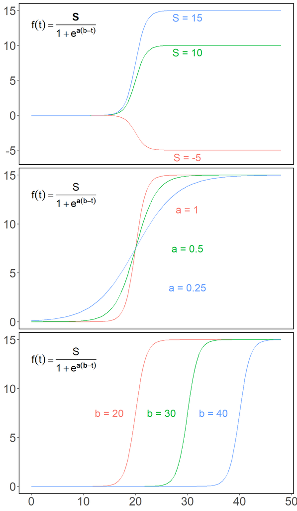

## The Data

```r
raw_file <- "data/data.parquet"

group_list <- c("sample", "wells", "dilutions", "assay", "reaction")

df_ <- raw_file %>%
  read_parquet() %>%
  mutate(
    across(c(reaction, wells, dilutions, assay, mortem, sample_type, animal, sample), as.factor)
  ) %>%
  select(-c(norm, deriv)) %>%
  filter(
    time != 0,
    sample %in% c("P"), time <= 72
  )

skim(df_)
```

Data summary

| Name | df_ |
| --- | --- |
| Number of rows | 193536 |
| Number of columns | 10 |
| _______________________ |  |
| Column type frequency: |  |
| factor | 8 |
| numeric | 2 |
| ________________________ |  |
| Group variables | None |

**Variable type: factor**

| skim_variable | n_missing | complete_rate | ordered | n_unique | top_counts |
| --- | --- | --- | --- | --- | --- |
| sample | 0 | 1 | FALSE | 1 | P: 193536, 196: 0, 197: 0, 197: 0 |
| wells | 0 | 1 | FALSE | 4 | A01: 48384, B01: 48384, C01: 48384, D01: 48384 |
| dilutions | 0 | 1 | FALSE | 1 | -3: 193536, -4: 0, -2: 0, -1: 0 |
| assay | 0 | 1 | FALSE | 2 | Nan: 96768, RT-: 96768 |
| reaction | 0 | 1 | FALSE | 168 | 202: 1152, 202: 1152, 202: 1152, 202: 1152 |
| animal | 0 | 1 | FALSE | 1 | Pos: 193536, 190: 0, 190: 0, 190: 0 |
| mortem | 0 | 1 | FALSE | 1 | pos: 193536, ant: 0 |
| sample_type | 0 | 1 | FALSE | 1 | PLN: 193536, MNP: 0, MNP: 0, NAD: 0 |

**Variable type: numeric**

| skim_variable | n_missing | complete_rate | mean | sd | p0 | p25 | p50 | p75 | p100 | hist |
| --- | --- | --- | --- | --- | --- | --- | --- | --- | --- | --- |
| time | 0 | 1 | 36.12 | 20.78 | 0.25 | 18.19 | 36.12 | 54.06 | 72 | ▇▇▇▇▇ |
| rfu | 0 | 1 | 4136.05 | 3280.11 | 141.00 | 1662.00 | 3492.00 | 5958.00 | 27707 | ▇▃▁▁▁ |

## Normalizing the Data

The data is first smoothed using a rolling mean, and then normalized to the eighth time point. The first and second derivatives were then estimated from the normalized data which made finding time points of inflection easier.

```r
norm_n_der <- function(df, x, y, norm_point, groups, window=3, smooth=10, zero=TRUE) {
  df %>%
    mutate(
      norm   = rollmean(!!sym(y), smooth, na.pad=TRUE),
      norm   = norm / norm[norm_point] - ifelse(zero, 1, 0),
      deriv  = (lead(norm, window) - lag(norm, window)) / (lead(!!sym(x), window) - lag(!!sym(x), window)),
      deriv2 = (lead(deriv, window) - lag(deriv, window)) / (lead(!!sym(x), window) - lag(!!sym(x), window)),
      .by = all_of(groups)
    )
}

df_test <- norm_n_der(df_, "time", "rfu", 8, group_list)
```

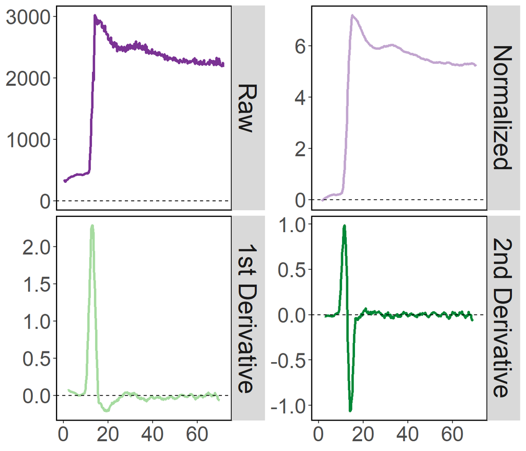

## Estimating Starting Values

The model uses the `nls()` function from the `stats` package. Because this is a parametric model, coefficients are first estimated using certain landmarks of the raw data.

```r
df_test_sum <- df_test %>%
  summarize(
    max_time             = max(time, na.rm=TRUE),
    max_deriv            = max(deriv, na.rm=TRUE),
    growth_scale         = max_deriv,
    peak_norm            = norm[which.min(deriv2)],
    time_to_growth_max   = time[norm == peak_norm][1],
    time_to_growth_mid   = time[which.max(deriv)],
    max_equillibrium     = max(norm[time >= time_to_growth_max], na.rm=TRUE),
    min_equillibrium     = min(norm[time >= time_to_growth_max], na.rm=TRUE),
    max_decay            = max_equillibrium - peak_norm,
    min_decay            = min_equillibrium - peak_norm,
    equillibrium         = ifelse(abs(min_decay) > max_decay, min_equillibrium, max_equillibrium),
    time_to_equillibrium = time[norm == equillibrium][1],
    peak_decay           = equillibrium - peak_norm,
    time_to_decay        = time_to_equillibrium - time_to_growth_max,
    time_to_decay_mid    = time_to_growth_max + time_to_decay / 2,
    decay_slope          = replace_na(peak_decay / time_to_decay, 0),
    decay_scale          = abs(decay_slope),
    .by = group_list
  )
```

## Fitting the Model

```r
fit_model <- function(data,
                      peak_norm,
                      time_to_growth_mid,
                      growth_scale,
                      peak_decay,
                      time_to_decay_mid,
                      decay_scale,
                      max_time,
                      ...) {
  form1 <- norm ~ (S1 / (1 + exp(a1 * (b1 - time))))
  form2 <- as.formula(paste(deparse(form1), "+ (S2 / (1 + exp(a2 * (b2 - time))))"))

  peak_scalar <- 2
  time_scalar <- 0.9

  lower_S1 <- 0
  lower_a1 <- 0
  lower_b1 <- 0.01
  lower_S2 <- -peak_norm * peak_scalar
  lower_a2 <- -peak_norm * peak_scalar
  lower_b2 <- time_to_growth_mid

  upper_S1 <- peak_norm * peak_scalar
  upper_a1 <- peak_norm * peak_scalar
  upper_b1 <- max_time * time_scalar
  upper_S2 <- peak_norm * peak_scalar
  upper_a2 <- peak_norm * peak_scalar
  upper_b2 <- max_time * time_scalar

  fit_single <- function() {
    single_mod <- NULL
    tryCatch(
      {
        single_mod <- nls(
          form1, data = data,
          start = list(
            S1 = peak_norm,
            a1 = peak_norm,
            b1 = time_to_growth_mid
          ),
          algorithm = "port",
          lower = c(S1 = lower_S1, a1 = lower_a1, b1 = lower_b1),
          upper = c(S1 = upper_S1, a1 = upper_a1, b1 = upper_b1)
        )
      },
      error = function(e) {
        sprintf("Unable to fit single modlel: %s", e)
      }
    )
    return(single_mod)
  }

  fit_double <- function(single_mod) {

    double_mod <- NULL

    try({
      double_mod <- nls(
        form2, data = data,
        start = list(
          S1 = peak_norm,  a1 = growth_scale, b1 = time_to_growth_mid,
          S2 = peak_decay, a2 = decay_scale,  b2 = time_to_decay_mid
        ),
        algorithm = "port",
        lower = c(
          S1 = lower_S1, a1 = lower_a1, b1 = lower_b1,
          S2 = lower_S2, a2 = lower_a2, b2 = lower_b2
        ),
        upper = c(
          S1 = upper_S1, a1 = upper_a1, b1 = upper_b1,
          S2 = upper_S2, a2 = upper_a2, b2 = upper_b2
        )
      )
    })

    if(is.null(double_mod) & !is.null(single_mod)) {
      try({
        coefs <- coef(single_mod)
        double_mod <- nls(
          form2, data = data,
          start = list(
            S1 = coefs[1],
            a1 = coefs[2],
            b1 = coefs[3],
            S2 = peak_decay,
            a2 = decay_scale,
            b2 = time_to_decay_mid
          ),
          algorithm = "port",
          lower = c(
            S1 = lower_S1, a1 = lower_a1, b1 = lower_b1,
            S2 = lower_S2, a2 = lower_a2, b2 = lower_b2
          ),
          upper = c(
            S1 = upper_S1, a1 = upper_a1, b1 = upper_b1,
            S2 = upper_S2, a2 = upper_a2, b2 = upper_b2
          )
        )
      })
    }

    if(is.null(double_mod)) return(single_mod)
    return(double_mod)
  }

  mod <- NULL
  try(mod <- fit_single(), silent = TRUE)
  try(mod <- fit_double(mod), silent = TRUE)
  return(mod)
}
```

## Results

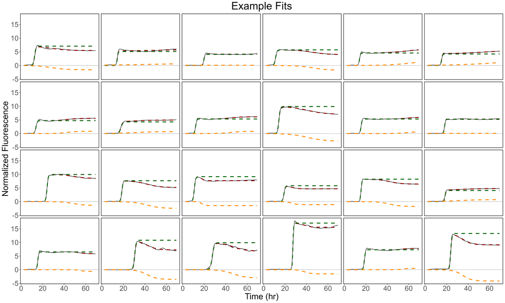

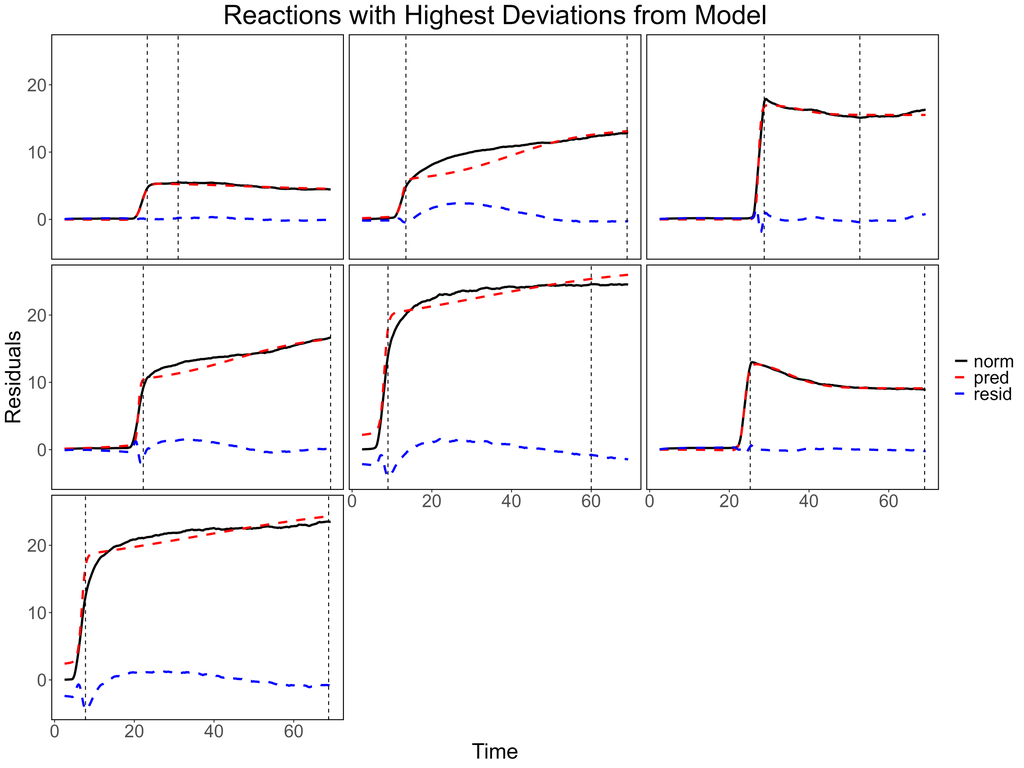

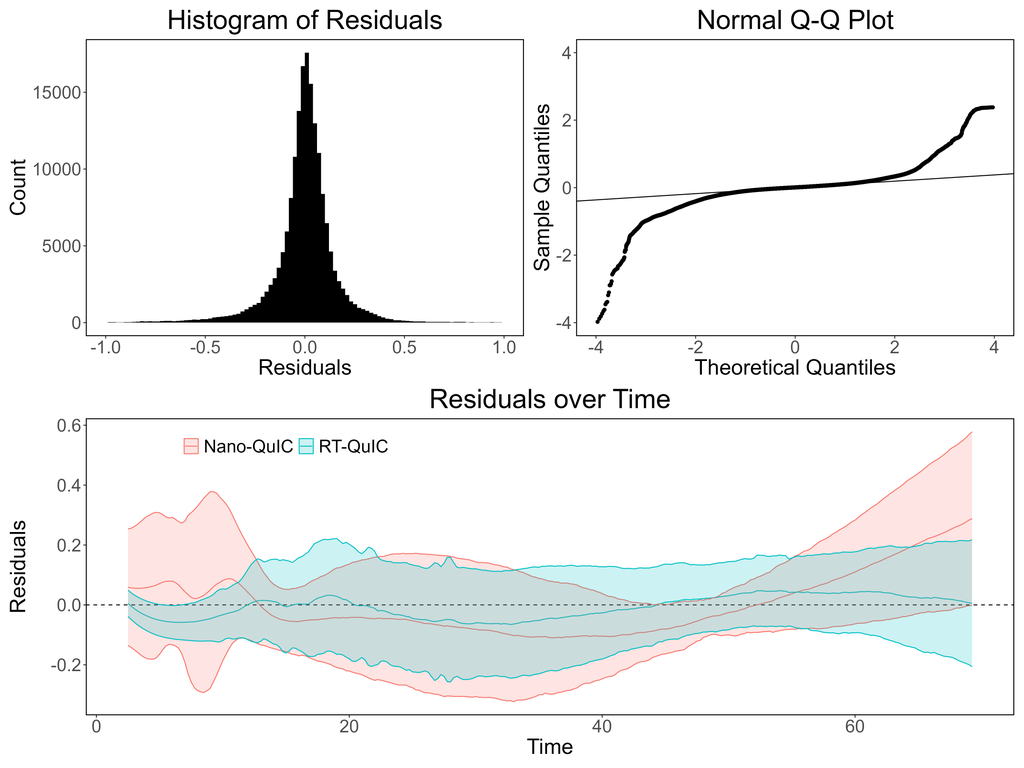

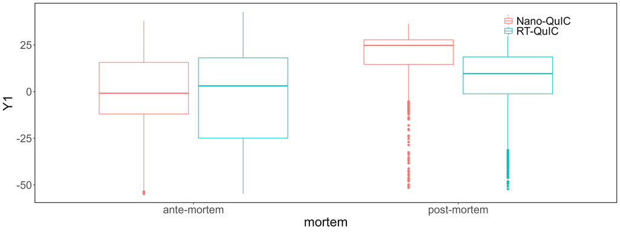